# Final Project Stock Priceess - Sentiment Analysis Data 607

Jaya Veluri

12/5/2021

## INTRODUCTION/OBJECTIVE

Analyze the daily stocks price changes(ex Tesla,Amazon) based on tweets on Twitter, extended the analysis of stock prices(Tesla,Amazon,Microsoft) with S&P 500 Index. Finally ported the tweets to Graph Dataframe.

## Tweets List From Tesla and Amazon

```r
tweet_list_TL <- searchTwitter("@AskTesla OR @TeslaInc OR @elonmusk OR @Tesla OR @TSLA OR @TSLAStock OR #TSLA OR #Tesla OR #TeslaInc" , n = 1000 , lang  = "en", since = "2021-09-01")
tweet_list_AMZN <- searchTwitter("@AmazonStock OR @AMZN OR @jeffBezos OR @Amazon OR @AMZNStock OR @Bezos OR #AMZN OR AMZN" , n = 1000 , lang  = "en", since = "2021-09-01")
```

### The returned tweets are initially stored in a list. For this project need them in a data frame and in text format.

```r
#Convert list to dataframe
tweetstl.df <- twListToDF(tweet_list_TL)
tweetsamzn.df <- twListToDF(tweet_list_AMZN)
#removing duplicate tweets (retweets) from dataframe
tweetstl.nodups.df <- distinct(tweetstl.df, text, .keep_all = TRUE)
tweetsamzn.nodups.df <- distinct(tweetsamzn.df, text, .keep_all = TRUE)
#clean up dataframe a bit TL
tweetstl.nodups.df$text <- gsub('…', '', tweetstl.nodups.df$text) #remove ... at end of tweets
tweetstl.nodups.df <- plyr::rename(tweetstl.nodups.df, c("created" = "Date")) #rename created to Date
tweetstl.nodups.df$Date <- as.Date(tweetstl.nodups.df$Date) #convert from datetime to date format
head(tweetstl.nodups.df,3)
```

```
##                                                                                                                                          text
## 1 RT @elonmusk: If “temporary” provisions in the Build Back Better Act become permanent, US national debt will increase by 24%! https://t.co/
## 2                                              @Acers_ @elonmusk You lost your savings because you you! Don’t blame others for your mistakes.
## 3                                 RT @elonmusk: Unless susceptible to extreme natural disasters, nuclear power plants should not be shut down
##   favorited favoriteCount replyToSN       Date truncated          replyToSID
## 1     FALSE             0      <NA> 2021-12-08     FALSE                <NA>
## 2     FALSE             0    Acers_ 2021-12-08     FALSE 1468690095838486528
## 3     FALSE             0      <NA> 2021-12-08     FALSE                <NA>
##                    id          replyToUID
## 1 1468695916072902664                <NA>
## 2 1468695915888271360 1174392431078465538
## 3 1468695913078034433                <NA>
##                                                                           statusSource
## 1   <a href="http://twitter.com/download/iphone" rel="nofollow">Twitter for iPhone</a>
## 2   <a href="http://twitter.com/download/iphone" rel="nofollow">Twitter for iPhone</a>
## 3 <a href="http://twitter.com/download/android" rel="nofollow">Twitter for Android</a>
##   screenName retweetCount isRetweet retweeted longitude latitude
## 1  MaseyLeah         3543      TRUE     FALSE        NA       NA
## 2  Coble3544            0     FALSE     FALSE        NA       NA
## 3   laylabtc         3322      TRUE     FALSE        NA       NA
```

```r
#clean up dataframe a bit AMZN
tweetsamzn.nodups.df$text <- gsub('…', '', tweetsamzn.nodups.df$text) #remove ... at end of tweets
tweetsamzn.nodups.df <- plyr::rename(tweetsamzn.nodups.df, c("created" = "Date")) #rename created to Date
tweetsamzn.nodups.df$Date <- as.Date(tweetsamzn.nodups.df$Date) #convert from datetime to date format
head(tweetsamzn.nodups.df,3)
```

```
##                                                                                                                                                                                        text
## 1                                               RT @mattwridley: Retweet this if you would like me to send you a personalised, signed copy of Viral—my new book on the search for the #Orig
## 2 Wagyu Cigars \nOne of my favorite #recipe you also will find it in my #cookbook ➡ PETIT CANAPÉS\n📖NEW ⚠NEW ⚠ NEW 📚\nNe https://t.co/fh0UxXubKm
## 3                         His quiet bachelor pad became a busy hive!\n★SWEET FASCINATION★\n✔Amazon https://t.co/7ADsSU0KiG\n✔Smashwords https://t.co/1K6RaOlX3p
##   favorited favoriteCount replyToSN       Date truncated replyToSID
## 1     FALSE             0      <NA> 2021-12-08     FALSE       <NA>
## 2     FALSE             0      <NA> 2021-12-08      TRUE       <NA>
## 3     FALSE             0      <NA> 2021-12-08      TRUE       <NA>
##                    id replyToUID
## 1 1468695958049406981       <NA>
## 2 1468695953494401029       <NA>
## 3 1468695951607054338       <NA>
##                                                                         statusSource
## 1 <a href="http://twitter.com/download/iphone" rel="nofollow">Twitter for iPhone</a>
## 2               <a href="https://dashboard.heropost.io/" rel="nofollow">Heropost</a>
## 3      <a href="https://www.socialjukebox.com" rel="nofollow">The Social Jukebox</a>
##        screenName retweetCount isRetweet retweeted longitude latitude
## 1      Dan_Astley          377      TRUE     FALSE        NA       NA
## 2       cheftipex            0     FALSE     FALSE        NA       NA
## 3 BridgitteLesley            0     FALSE     FALSE        NA       NA
```

```r
#create text list with tweets for sentiment analysis TL
tweets_text_tl <- lapply(tweet_list_TL, function(x) x$getText())
tweets_text_tl <- sapply(tweets_text_tl,function(row) iconv(row, "latin1", "ASCII", sub=""))
tweets_nodups_text_tl <- unique(tweets_text_tl)

#create text list with tweets for sentiment analysis AMZN
tweets_text_amzn <- lapply(tweet_list_AMZN, function(x) x$getText())
tweets_text_amzn <- sapply(tweets_text_amzn,function(row) iconv(row, "latin1", "ASCII", sub=""))
tweets_nodups_text_amzn <- unique(tweets_text_amzn)
```

## Exploring the tweets(Create tweet corpus)

examine a word cloud of the tweets to see the types of words that make up the returned tweets.

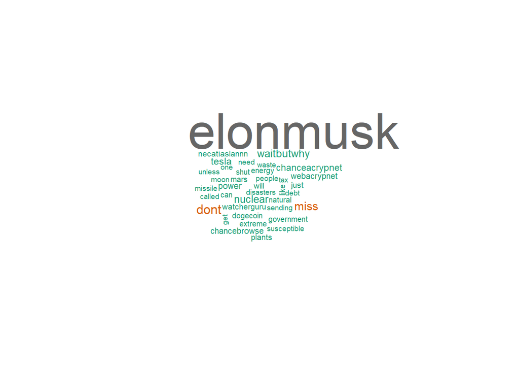

```r
#Create tweet corpus
r_stats_text_corpus_ttl <- Corpus(VectorSource(tweets_nodups_text_tl))
r_stats_text_corpus_amzn <- Corpus(VectorSource(tweets_nodups_text_amzn))
#Clean up corpus in prepartion for word cloud
r_stats_text_corpus_ttl <- tm_map(r_stats_text_corpus_ttl, content_transformer(tolower))
r_stats_text_corpus_amzn <- tm_map(r_stats_text_corpus_amzn, content_transformer(tolower))
#Transform all text to lower case
r_stats_text_corpus_ttl <- tm_map(r_stats_text_corpus_ttl, removePunctuation)
r_stats_text_corpus_amzn <- tm_map(r_stats_text_corpus_amzn, removePunctuation)
#remove all punctuation
r_stats_text_corpus_ttl <- tm_map(r_stats_text_corpus_ttl, function(x)removeWords(x,stopwords()))
r_stats_text_corpus_amzn <- tm_map(r_stats_text_corpus_amzn, function(x)removeWords(x,stopwords()))
#remove all stop words
#Apply sentiment to words
#Create color word cloud
wordcloud(r_stats_text_corpus_ttl, min.freq = 10, max.words = 150, colors=brewer.pal(8, "Dark2"))
```

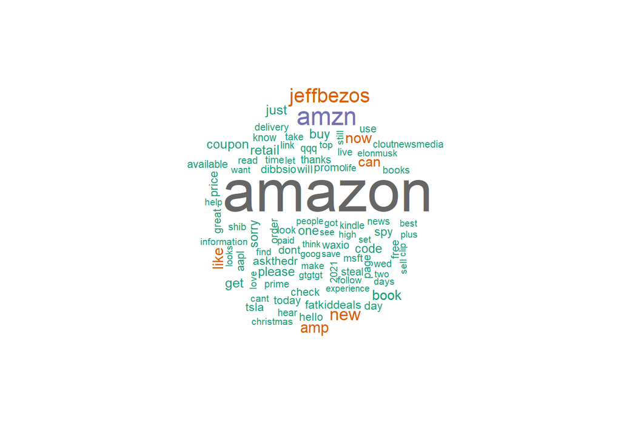

```r
wordcloud(r_stats_text_corpus_amzn, min.freq = 10, max.words = 150, colors=brewer.pal(8, "Dark2"))
```

## Sentiment Analysis For our sentiment analysis we will use a function created that uses a published lexicon of positive and negative words. This function will create a score for each tweet. A score of 0 indicates the tweet is neutral. A score of 1 or more indicates the tweet is positive. A score of -1 or less indicates the tweet is negative. The higher (or lower) the number indicates the relative strength of the sentiment (based on the count of words).

```r
score.sentiment = function(sentences, pos.words, neg.words, .progress='none')
{
  require(plyr)
  require(stringr)

  # we got a vector of sentences. plyr will handle a list or a vector as an "l" for us
  # we want a simple array of scores back, so we use "l" + "a" + "ply" = laply:
  scores = laply(sentences, function(sentence, pos.words, neg.words) {

    # clean up sentences with R's regex-driven global substitute, gsub():
    sentence = gsub('[[:punct:]]', '', sentence)
    sentence = gsub('[[:cntrl:]]', '', sentence)
    sentence = gsub('\\d+', '', sentence)
    # and convert to lower case:
    sentence = tolower(sentence)

    # split into words. str_split is in the stringr package
    word.list = str_split(sentence, '\\s+')
    # sometimes a list() is one level of hierarchy too much
    words = unlist(word.list)

    # compare our words to the dictionaries of positive & negative terms
    pos.matches = match(words, pos.words)
    neg.matches = match(words, neg.words)

    # match() returns the position of the matched term or NA
    # we just want a TRUE/FALSE:
    pos.matches = !is.na(pos.matches)
    neg.matches = !is.na(neg.matches)

    # and conveniently enough, TRUE/FALSE will be treated as 1/0 by sum():
    score = sum(pos.matches) - sum(neg.matches)

    return(score)
  }, pos.words, neg.words, .progress=.progress )

  scores.df = data.frame(score=scores, text=sentences)
  return(scores.df)
}
#The positive and negative words lexicons are stored in a local director
#Please see appendix/reference for more information on origin
hu.liu.pos = scan('https://raw.githubusercontent.com/jayatveluri/DataAcquisition/main/positive-words.txt', what = 'character', comment.char = ';')
hu.liu.neg = scan('https://raw.githubusercontent.com/jayatveluri/DataAcquisition/main/negative-words.txt', what = 'character', comment.char = ';')

#Here we add some additional words that were discovered from initial review of tweets
pos.words <- c(hu.liu.pos)
neg.words <- c(hu.liu.neg, 'wait', 'waiting', 'hold', 'onhold' , 'on hold', 'asshole', 'cancel','spam', 'spams', 'cancel', 'wtf')
```

## Run the sentiment function on the text of the tweets

```r
tesla.scores <- score.sentiment(tweets_nodups_text_tl, pos.words, neg.words, .progress='none')
amazon.scores <- score.sentiment(tweets_nodups_text_amzn, pos.words, neg.words, .progress='none')
```

### merge the results back with the original file

```r
tesla.scores.merge <- merge(tesla.scores, tweetstl.nodups.df, by = 'text')
amazon.scores.merge <- merge(amazon.scores, tweetsamzn.nodups.df, by = 'text')
```

## Histogram of sentiment for all tweets

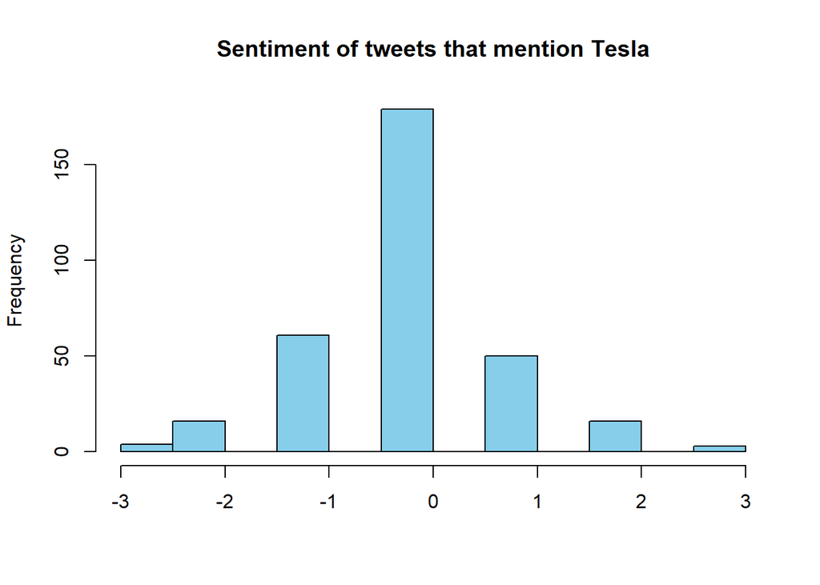

```r
hist(tesla.scores.merge$score,xlab=" ",main="Sentiment of tweets that mention Tesla",
     border="black",col="skyblue")
```

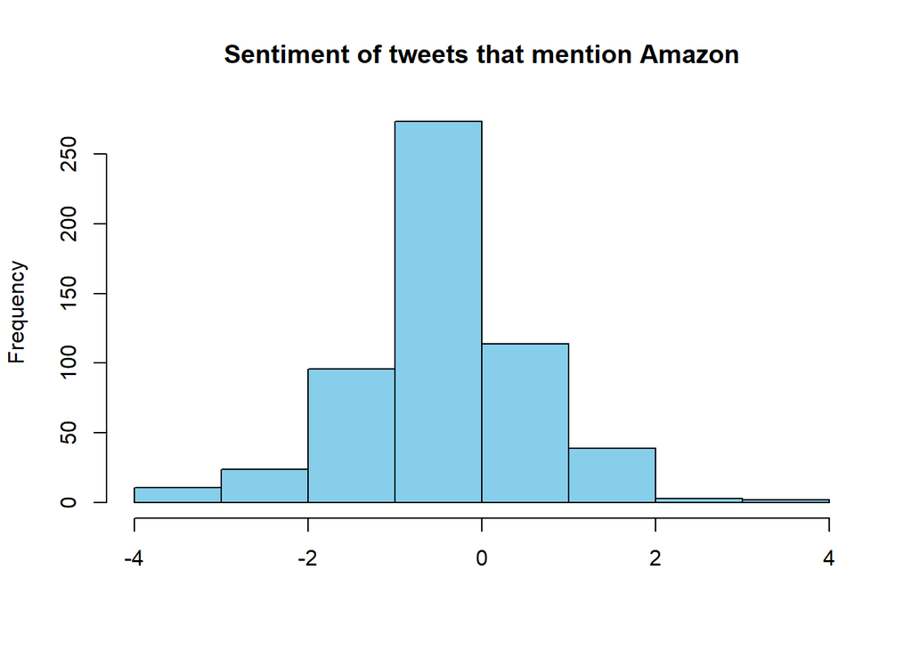

```r
hist(amazon.scores.merge$score,xlab=" ",main="Sentiment of tweets that mention Amazon",
     border="black",col="skyblue")
```

## Scatter plot of tweet date vs sentiment score

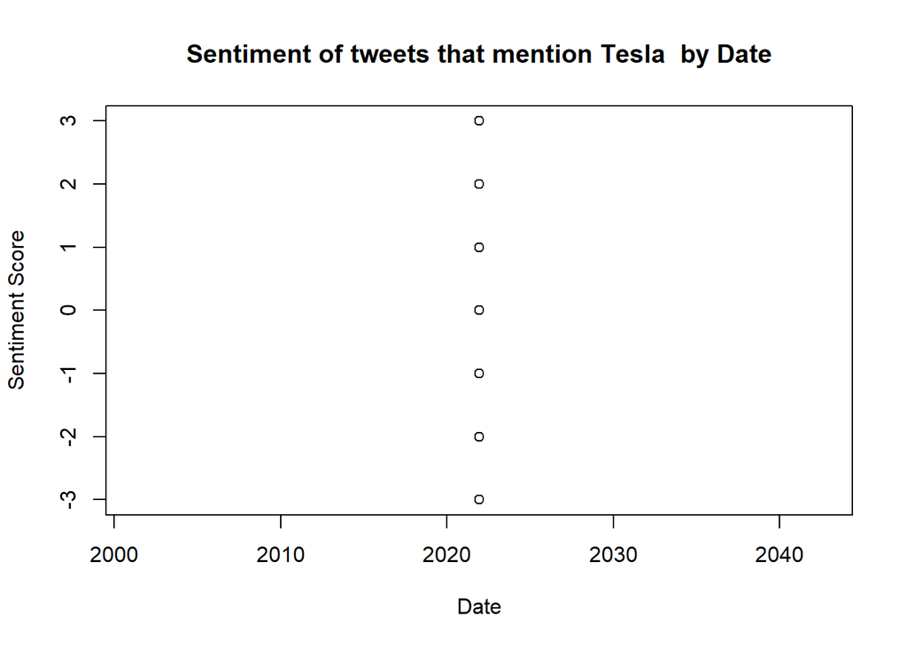

```r
plot(tesla.scores.merge$Date, tesla.scores.merge$score, xlab = "Date", ylab = "Sentiment Score", main = "Sentiment of tweets that mention Tesla  by Date")
```

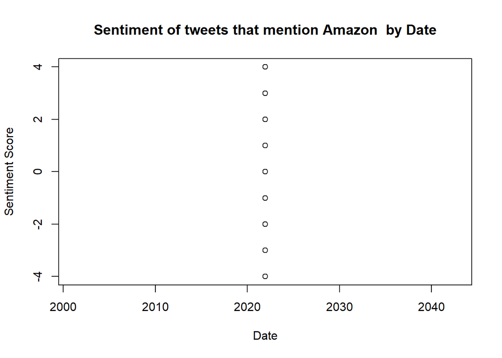

```r
plot(amazon.scores.merge$Date, amazon.scores.merge$score, xlab = "Date", ylab = "Sentiment Score", main = "Sentiment of tweets that mention Amazon  by Date")
```

## TESLA total evaluation: positive / negative / neutral

```r
tlstat <- tesla.scores.merge$score
tlstat <- mutate(tesla.scores.merge, tweet=ifelse(tesla.scores.merge$score > 0, 'positive', ifelse(tesla.scores.merge$score < 0, 'negative', 'neutral')))
tlby.tweet <- group_by(tlstat, tweet, Date)
tlby.tweet <- dplyr::summarise(tlby.tweet, number=n())
tlby.tweet
```

```
## # A tibble: 3 x 3
## # Groups:   tweet [3]
##   tweet    Date       number
##   <chr>    <date>      <int>
## 1 negative 2021-12-08     81
## 2 neutral  2021-12-08    179
## 3 positive 2021-12-08     69
```

```
## geom_path: Each group consists of only one observation. Do you need to adjust
## the group aesthetic?
```

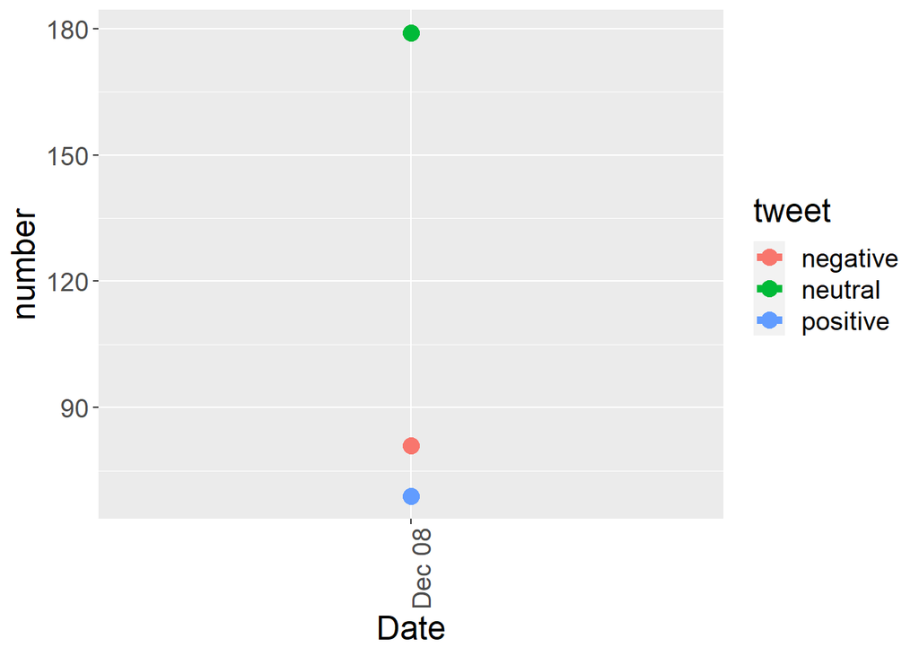

```r
#Sentiment (positive, negative and neutral) over time
ggplot(tlby.tweet, aes(Date, number)) + geom_line(aes(group=tweet, color=tweet), size=2) +
  geom_point(aes(group=tweet, color=tweet), size=4) +
  theme(text = element_text(size=18), axis.text.x = element_text(angle=90, vjust=1))
```

## AMAZON total evaluation: positive / negative / neutral

```r
amznstat <- amazon.scores.merge$score
amznstat <- mutate(amazon.scores.merge, tweet=ifelse(amazon.scores.merge$score > 0, 'positive', ifelse(amazon.scores.merge$score < 0, 'negative', 'neutral')))
amznby.tweet <- group_by(amznstat, tweet, Date)
amznby.tweet <- dplyr::summarise(amznby.tweet, number=n())
amznby.tweet
```

```
## # A tibble: 3 x 3
## # Groups:   tweet [3]
##   tweet    Date       number
##   <chr>    <date>      <int>
## 1 negative 2021-12-08    131
## 2 neutral  2021-12-08    273
## 3 positive 2021-12-08    158
```

```
## geom_path: Each group consists of only one observation. Do you need to adjust
## the group aesthetic?
```

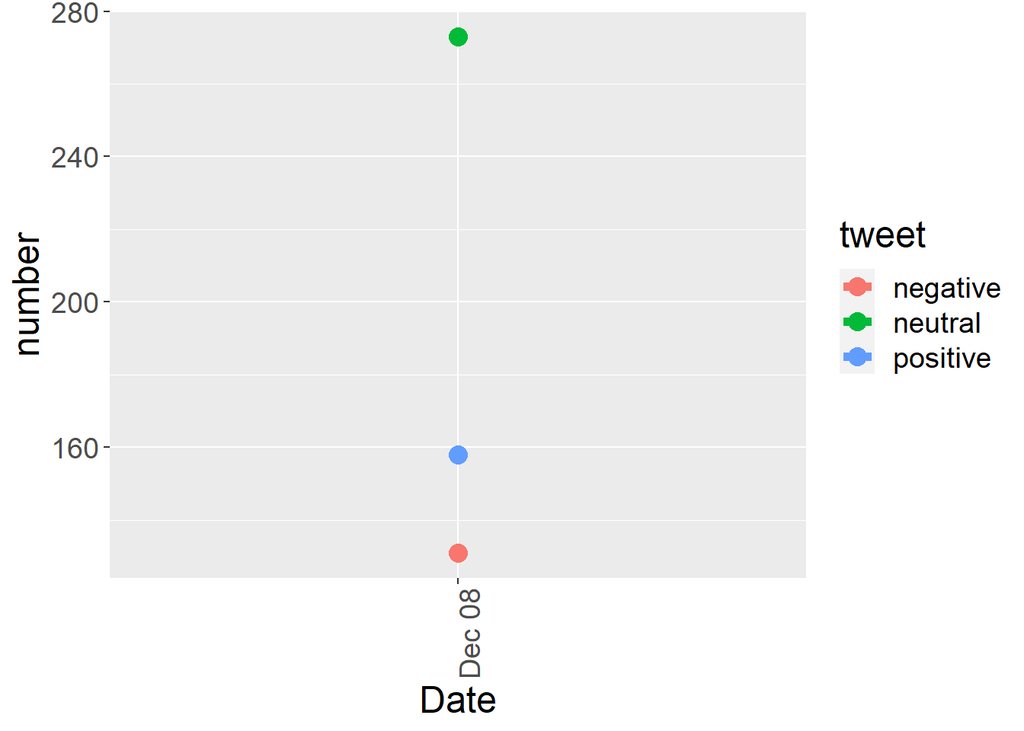

```r
#Sentiment (positive, negative and neutral) over time
ggplot(amznby.tweet, aes(Date, number)) + geom_line(aes(group=tweet, color=tweet), size=2) +
  geom_point(aes(group=tweet, color=tweet), size=4) +
  theme(text = element_text(size=18), axis.text.x = element_text(angle=90, vjust=1))
```

## Tesla Correlation with Stock Prices

```r
#Read stock price CSV in
stock_prices_tl <- read.csv("https://raw.githubusercontent.com/jayatveluri/DataAcquisition/main/TSLA.csv")

#Format date so R knows this is a date field
stock_prices_tl$Date <- as.Date(stock_prices_tl$Date, "%m/%d/%y")

#Left join the sentiment analysis with the stock prices
tweet_stock_tl <- left_join(tesla.scores.merge, stock_prices_tl, by = "Date")
tweet_stock_tl  <-  select(tweet_stock_tl, c('score', 'text'))
tweet_stock_tl <- head(tweet_stock_tl, 10)
tweet_stock_tl
```

```
##    score
## 1     -1
## 2     -1
## 3      0
## 4      0
## 5     -1
## 6      1
## 7      1
## 8      0
## 9      1
## 10     1
##                                                                                                                                           text
## 1  $JAR partenered with #Tesla x1000 move is coming\n$BUSD $WBTC $LTC $vra $IOST $cvc $LTC $LTC $ETH $CHSB $DENT $avax https://t.co/lPPHpF8lo0
## 2                                                                                  @0xPete_ @elonmusk Until earthquake. Terrorism. Flood. War.
## 3  @4ThePlayer @combatchris3 @JeffHut14 @eddie82s @PaulNeal123 @NecatiAslannn @elonmusk Nothing is riskless, people fa https://t.co/wWQ9DvhX3Z
## 4  @4ThePlayer @eddie82s @PaulNeal123 @NecatiAslannn @elonmusk Mate go look at where the brits, yanks, koreans, etc bu https://t.co/uCKzC7B7H8
## 5  @4ThePlayer @JeffHut14 @eddie82s @PaulNeal123 @NecatiAslannn @elonmusk The Fukushima nuclear disaster may have caus https://t.co/bhDakKgAjd
## 6  @AbolishApathy @Jafpro_16 @JeffTutorials @elonmusk Those sound like general welfare to me, which is one of the resp https://t.co/Oc8Mg5pKT9
## 7                                                                  @Abrvhm @Stoney_Case @elonmusk And it passed easily with bipartisan support
## 8  @AethonRose @NecatiAslannn @elonmusk Plus they recycle their spent fuel rods along with the rest of Europe... Sound https://t.co/r6JCw57GeT
## 9  @andrew1ups @NecatiAslannn @elonmusk Fact is fossil fuels will run out. Not in my lifetime but soon enough. Nuclear https://t.co/sKpwOC5hGx
## 10 @Antification @elonmusk They should never. Why? To have a backbone. You can't fully rely on only renewables which i https://t.co/FM6Ra4pnkS
```

## Amazon Correlation with Stock Prices

```r
#Read stock price CSV in
stock_prices_amzn <- read.csv("https://raw.githubusercontent.com/jayatveluri/DataAcquisition/main/AMZN.csv")

#Format date so R knows this is a date field
stock_prices_amzn$Date <- as.Date(stock_prices_amzn$Date, "%m/%d/%y")

#Left join the sentiment analysis with the stock prices
tweet_stock_amzn <- left_join(amazon.scores.merge, stock_prices_amzn, by = "Date")
tweet_stock_amzn  <-  select(tweet_stock_amzn, c('score', 'text'))
tweet_stock_amzn <- head(tweet_stock_amzn, 10)
tweet_stock_amzn
```

```
##    score
## 1      0
## 2      0
## 3      0
## 4      0
## 5      0
## 6     -1
## 7      0
## 8     -1
## 9     -1
## 10    -1
##                                                                                                                                               text
## 1  'a wild megalomaniacal trip into the American spiritual &amp; Cultural   Revolution of the 1960s-90s...a young southern https://t.co/w86FNrBn80
## 2                                                   "nl: Alex Rider S02E01 Surf 1080p AMZN WEB-DL DDP5 1 H 264-MZABI downloaded from opensubtitles
## 3                                                   "nl: Alex Rider S02E02 Hunt 1080p AMZN WEB-DL DDP5 1 H 264-MZABI downloaded from opensubtitles
## 4                                                 "nl: Alex Rider S02E03 Mirror 1080p AMZN WEB-DL DDP5 1 H 264-MZABI downloaded from opensubtitles
## 5                                                "nl: Alex Rider S02E04 Serpent 1080p AMZN WEB-DL DDP5 1 H 264-MZABI downloaded from opensubtitles
## 6                                                "nl: Alex Rider S02E05 Threats 1080p AMZN WEB-DL DDP5 1 H 264-MZABI downloaded from opensubtitles
## 7                                                  "nl: Alex Rider S02E06 Heist 1080p AMZN WEB-DL DDP5 1 H 264-MZABI downloaded from opensubtitles
## 8                                               "nl: Alex Rider S02E07 Assassin 1080p AMZN WEB-DL DDP5 1 H 264-MZABI downloaded from opensubtitles
## 9                                                 "nl: Alex Rider S02E08 Strike 1080p AMZN WEB-DL DDP5 1 H 264-MZABI downloaded from opensubtitles
## 10                                   "See"my new book When the Dead Speak  https://t.co/XOVI68Wuf2 https://t.co/vMDu28mooE https://t.co/v7H3chwDwo
```

[figure not shown]

```r
plot(jitter(tweet_stock_tl$score), tweet_stock_tl$Daily.Change, xlab = "Sentiment Score", ylab = "Tesla Daily Change in Stock Price")
```

[figure not shown]

```r
plot(jitter(tweet_stock_amzn$score), tweet_stock_amzn$Daily.Change, xlab = "Sentiment Score", ylab = "Amazon Daily Change in Stock Price")
```